# Single seed microbiota: assembly and transmission from parent plant to seedling

Chesneau et al., 2021

21/05/2021

# Before you start

This script has been made on R 4.0.0 (and Rstudio 1.2.5019)

```r
R.version
```

```
##                _
## platform       x86_64-w64-mingw32
## arch           x86_64
## os             mingw32
## system         x86_64, mingw32
## status
## major          4
## minor          0.0
## year           2020
## month          04
## day            24
## svn rev        78286
## language       R
## version.string R version 4.0.0 (2020-04-24)
## nickname       Arbor Day
```

```r
#Load theme set
library(ggplot2)
theme_set(theme_bw())
```

# Data information

**Project:** ANR SEEDS

**Experiment 2 :** “Community assembly at the individual seed level”

**Factors :**

- Plant species : bean (*Phaseolus vulgaris*) and radish (*Raphanus sativus*)
- Habitats sampled : Buds flower, Open flowers, Seeds, Stem, Air
- Seed developmental stages : D27, D33, D42, D50 (bean) and D26, D37, D65 (radish)
- At each developmental 5-7 plants were harvested. 720-480 seeds (bean-radish) / 150 bacterial mates
- DNA extraction : MN Food on CFU - after enrichment on TSA10%
- Primers : v4 region of 16S rRNA gene (Caporaso et al., 2011) and *gyrB* (Barret et al., 2015)
- 3 sequencing runs (MiSeq v2 - 500 cycles )

# 1- Seed water content

For each plant (5) sampled at each stage of seed development, fresh weight and dry weight of a bulk of 15 seeds were measured to estimate their water content.

```
## [1] '1.1.1'
```

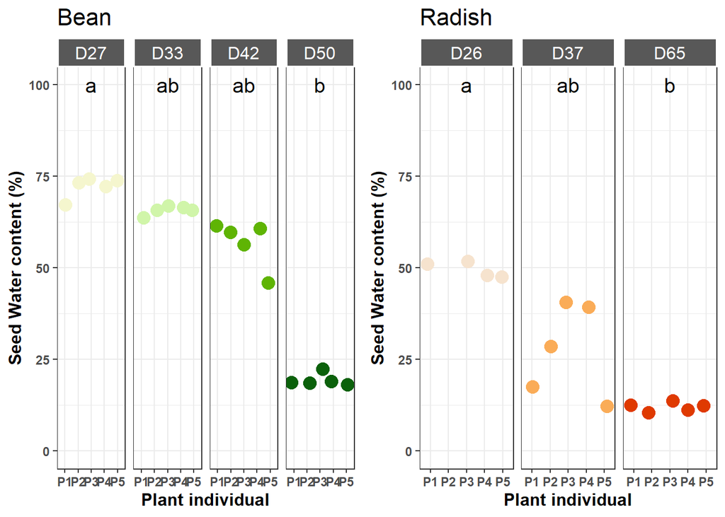

# 2 - Number of CFU

### 2.1 - Percentage of contamination per stage

We splitted our dataset in 2 parts :

- Contamination = No, no CFU detected on the plate
- Contamination = yes, at least 1 CFU on the plate

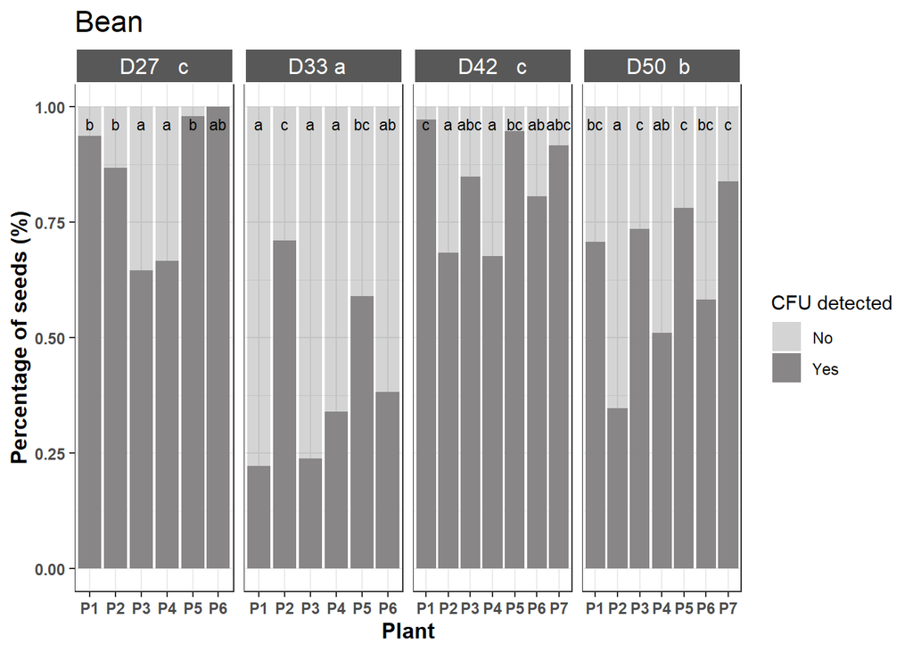

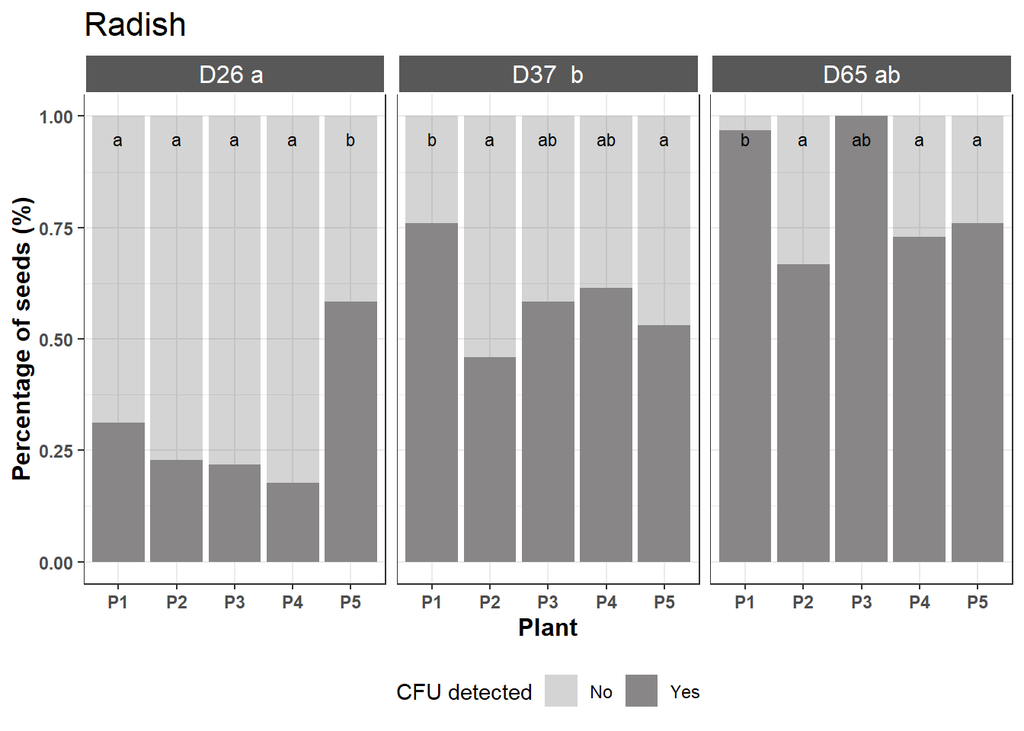

# 3 - Sequence analyses

## 3.1 - Remove primers with cutadapt v1.15

```
for i in `cat group`; do cutadapt --discard-untrimmed -o $i.gyrB.R1.fq -p $i.gyrB.R2.fq -g MGNCCNGSNATGTAYATHGG -G ACNCCRTGNARDCCDCCNGA -e 0.1  -O 20 $i*L001_R1_001.fastq.gz $i*_L001_R2_001.fastq.gz; done
for i in `cat group`; do cutadapt --discard-untrimmed -o $i.16S.R1.fq -p $i.16S.R2.fq -g GTGCCAGCMGCCGCGGTAA -G GGACTACHVGGGTWTCTAAT -e 0 -O 19 $i*_L001_R1_001.fastq.gz $i*_L001_R2_001.fastq.gz; done
```

## 3.2 - Convert fastq to ASV table (dada2)

To save computing time, the code is not evaluated in the version of the document and the results are not included.

# 4 - Filtering data

## 4.1 - Construct phyloseq objects

*gyrB : 6784 taxa and 1536 samples*  
*16S : 3505 taxa and 1536 samples*

## 4.2 - ASVs filtering

- Remove empty samples
- Filtered ASVs based on taxonomy
- Rename ASVs
- Assess distribution of ASVs in positive and negative controls
- Subset Samples (remove sample with less than 1000 reads per sample)

## 4.3 - Phylogenetic tree

Neighbor-Joining tree were constructed the packages DECIPHER v 2.12.0 and Phangorn v 2.5.5 using default paramaters.

**After filtering**

- 2738 taxa and 1424 samples

**Save merged PS objects with phylogenetic tree**

## 4.4 - Remove contaminants with decontam

Unfiltered

Filtered

*After decontamination with decontam (R package)* The decontam package provides simple statistical methods to identify and visualize contaminating DNA features, allowing them to be removed and a more accurate picture of sampled communities to be constructed from marker-gene and metagenomics data.

We used the “prevalence” method. In this method, the prevalence (presence/absence across samples) of each sequence feature in true positive samples is compared to the prevalence in negative controls to identify contaminants.

**Save merged PS objects with phylogenetic tree**

*gyrB:*

phyloseq-class experiment-level object  
otu_table() OTU Table: [ 4815 taxa and 1398 samples ]  
sample_data() Sample Data: [ 1398 samples by 18 sample variables ]  
tax_table() Taxonomy Table: [ 4815 taxa by 7 taxonomic ranks ]  
phy_tree() Phylogenetic Tree: [ 4815 tips and 4813 internal nodes ]  
refseq() DNAStringSet: [ 4815 reference sequences ]

*16S :*

phyloseq-class experiment-level object  
otu_table() OTU Table: [ 2738 taxa and 1424 samples ]  
sample_data() Sample Data: [ 1424 samples by 18 sample variables ]  
tax_table() Taxonomy Table: [ 2738 taxa by 6 taxonomic ranks ]  
phy_tree() Phylogenetic Tree: [ 2738 tips and 2737 internal nodes ]  
refseq() DNAStringSet: [ 2738 reference sequences ]

# 5 - Dataset 2

```
## [1] '1.32.0'
```

*d16S :*  
*dgyrB:*

To found out which samples are in this dataset please refer to Data information section.

## 5.1 - Sequencing depth

We first assess the number of sequences per sample

We next performed rarefaction curves

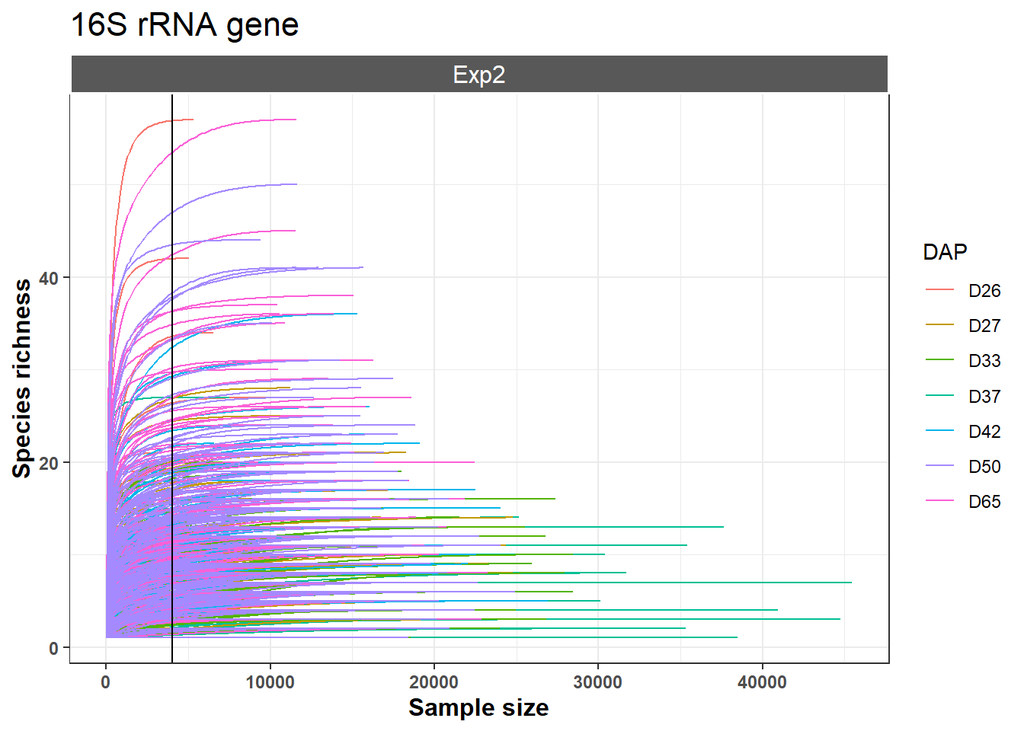

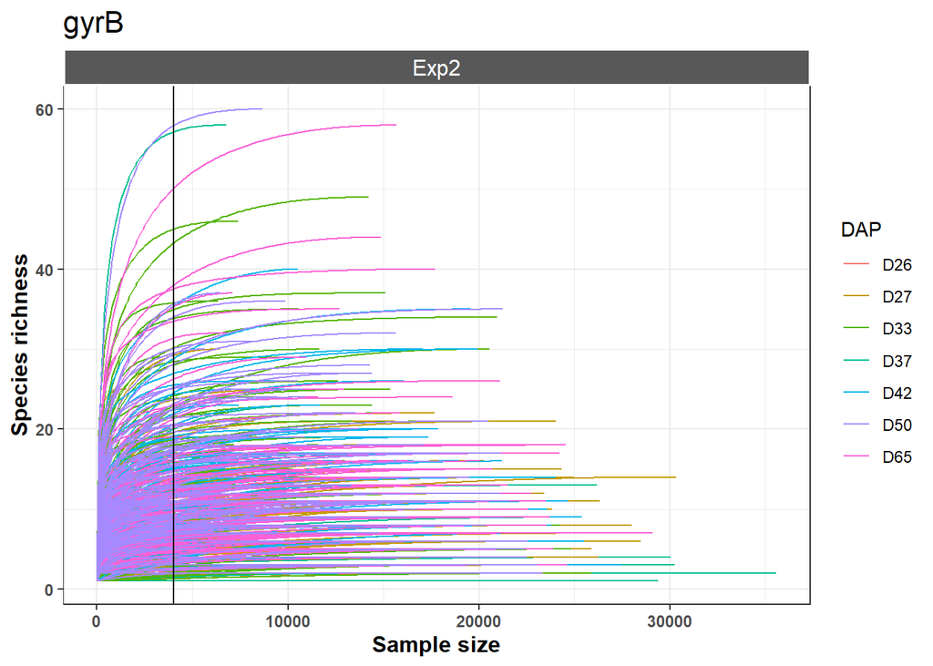

## 5.2 - Alpha diversity analysis

In this part we used rarefy data :

- **16S** : 4,000 reads per sample
- **gyrB** : 4,000 reads per sample

*Figure alpha diversity*

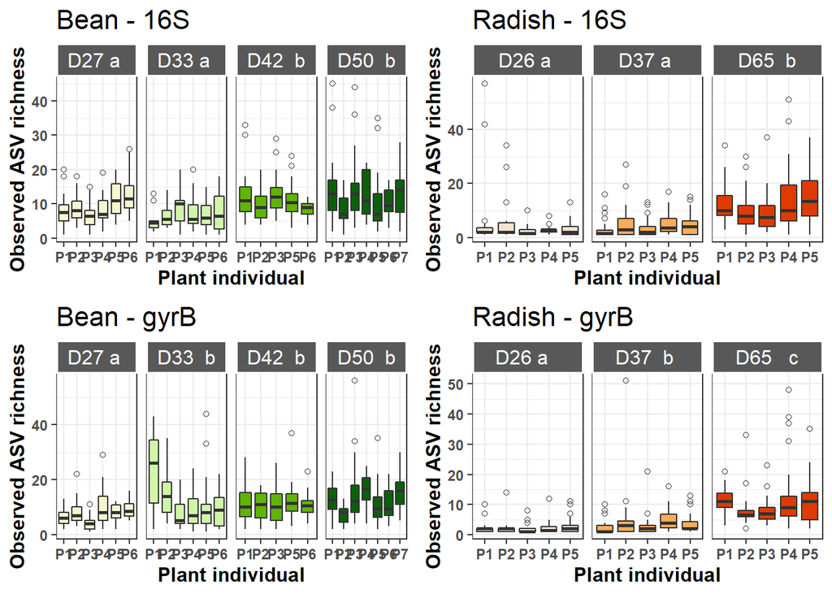

## 5.3 - Correlation CFU/Richness

we performed correlation between number of CFU per seed and richness.

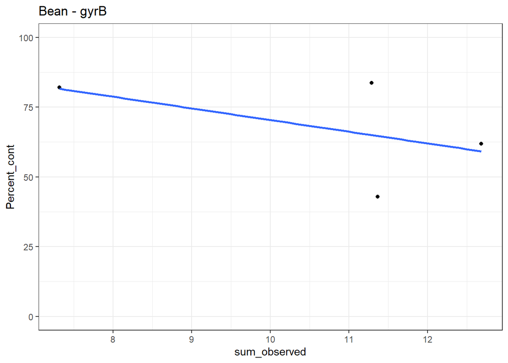

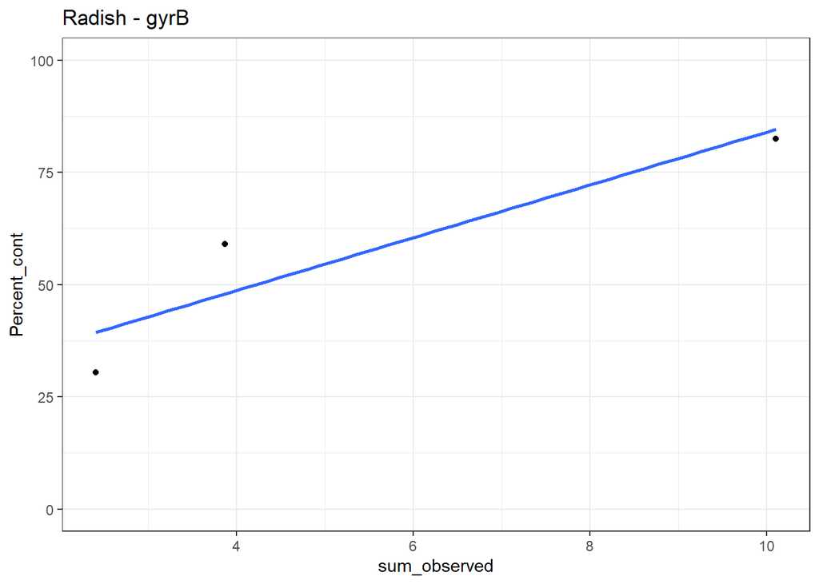

## 5.4 - Taxonomic composition

Evaluation of the taxonomic composition at the individual seed level.

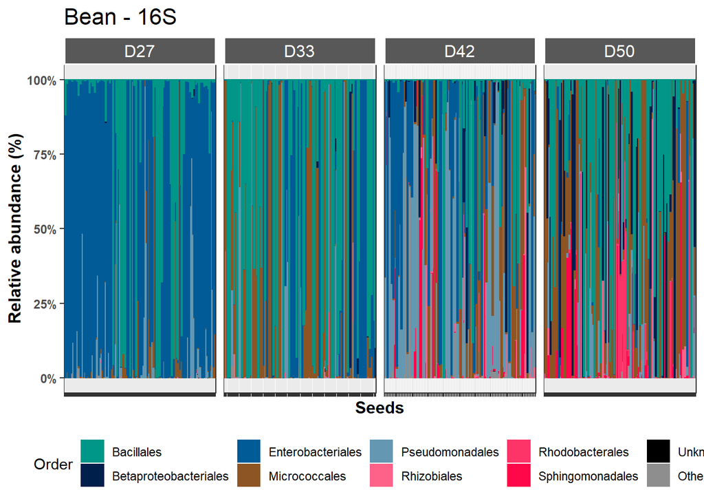

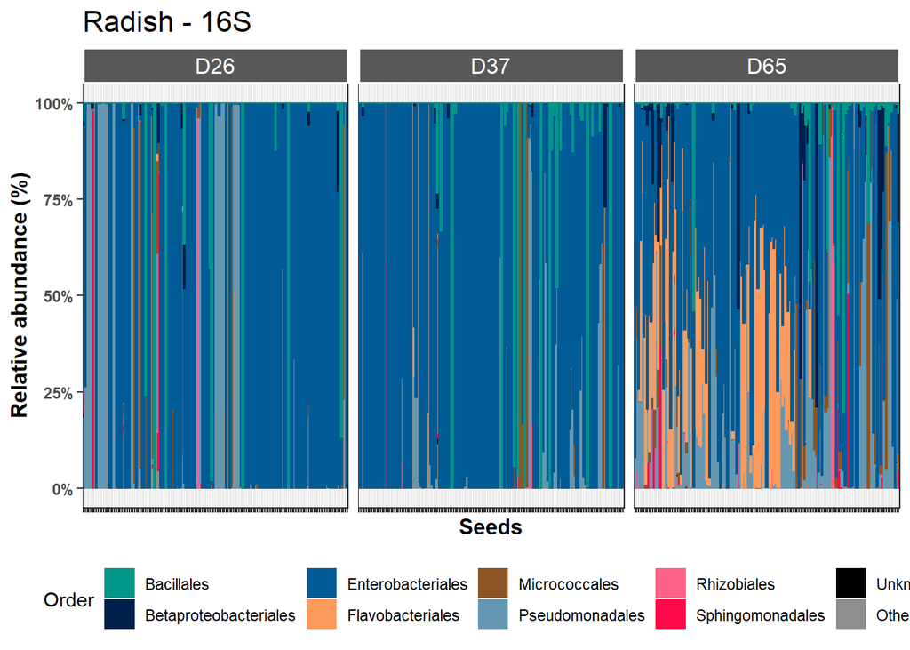

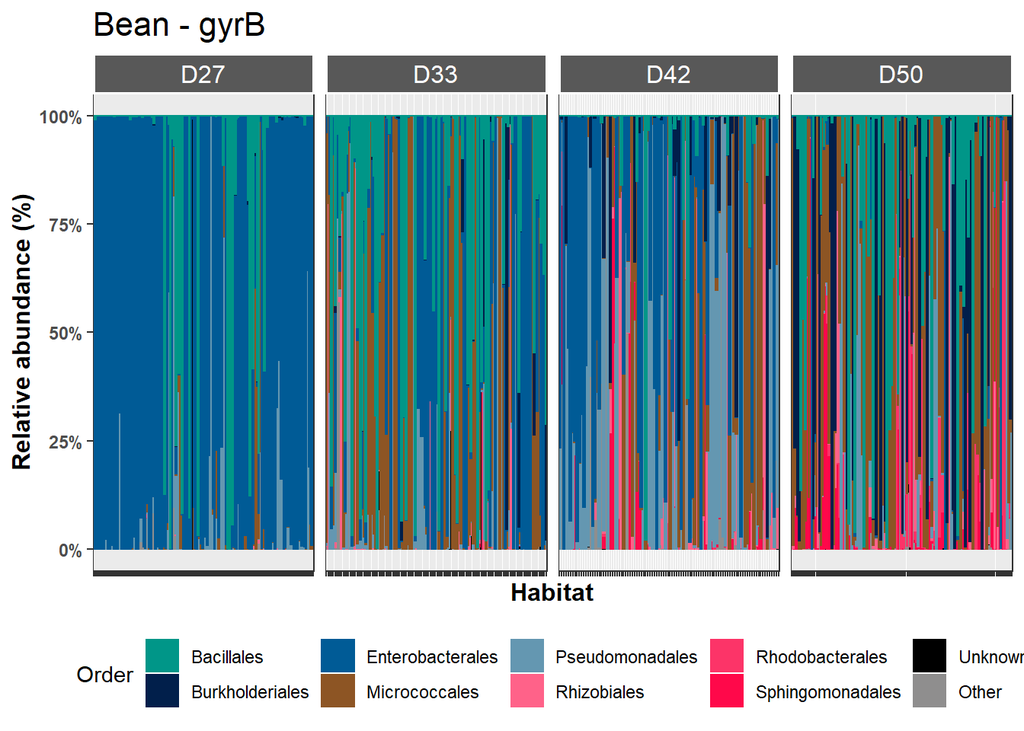

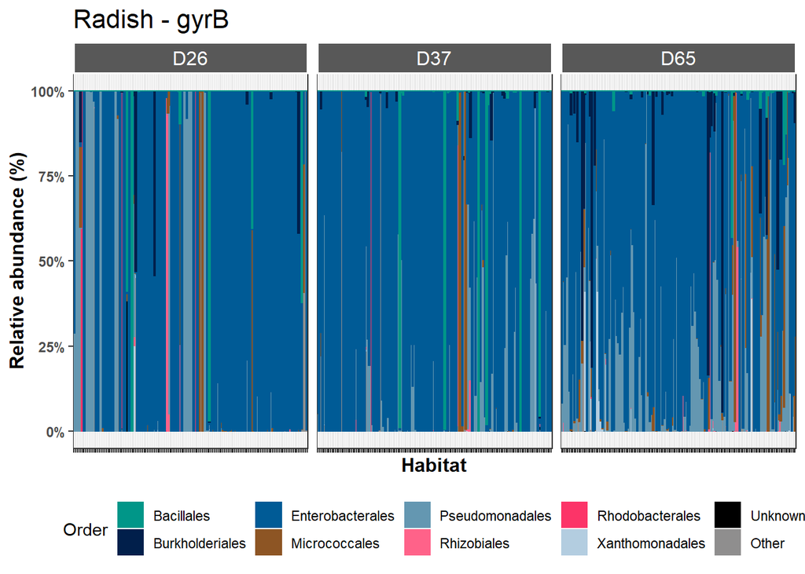

## 5.5 Permanova Stages / Plants

Importance of stages of seed development and spatial heteorgenity (plant) on seed microbiota composition.

```
## Permutation test for adonis under reduced model
## Terms added sequentially (first to last)
## Permutation: free
## Number of permutations: 999
##
## adonis2(formula = wUF.16Sb ~ DAP/Plant, data = mdat.16Sb, permutations = 999)
##            Df SumOfSqs      R2       F Pr(>F)
## DAP         3   16.828 0.18320 42.4494  0.001 ***
## DAP:Plant  20    7.501 0.08166  2.8383  0.001 ***
## Residual  511   67.526 0.73513
## Total     534   91.856 1.00000
## ---
## Signif. codes:  0 '***' 0.001 '**' 0.01 '*' 0.05 '.' 0.1 ' ' 1
```

# 6 - Rank abundance

## 6.1 - Measure rank abundance

Measure abundance of rank 1, rank 2, rank 3… taxa for each individual seed at each stage of development.

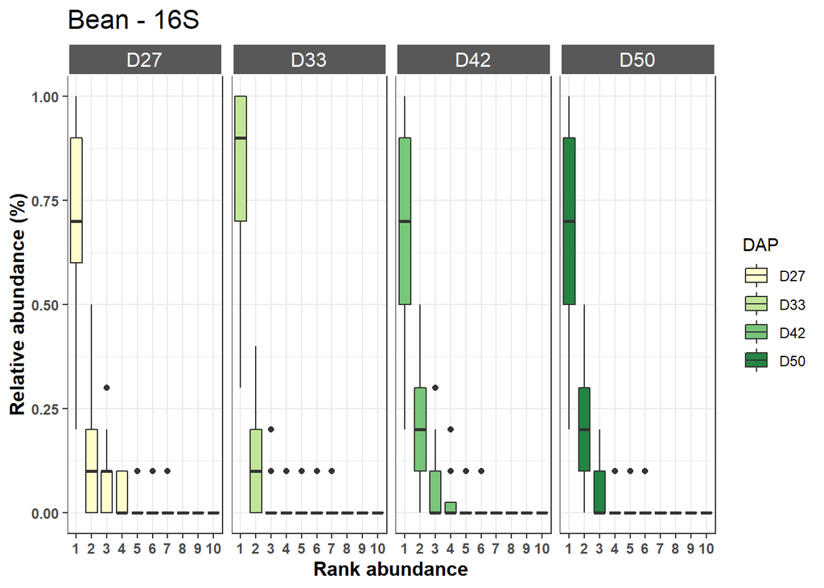

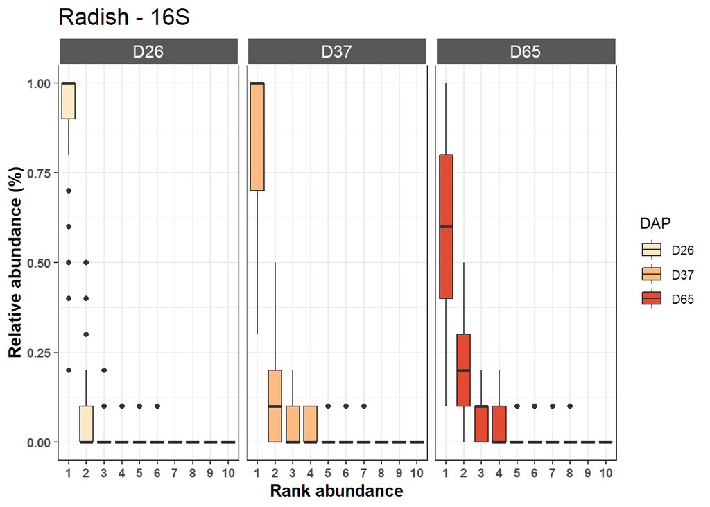

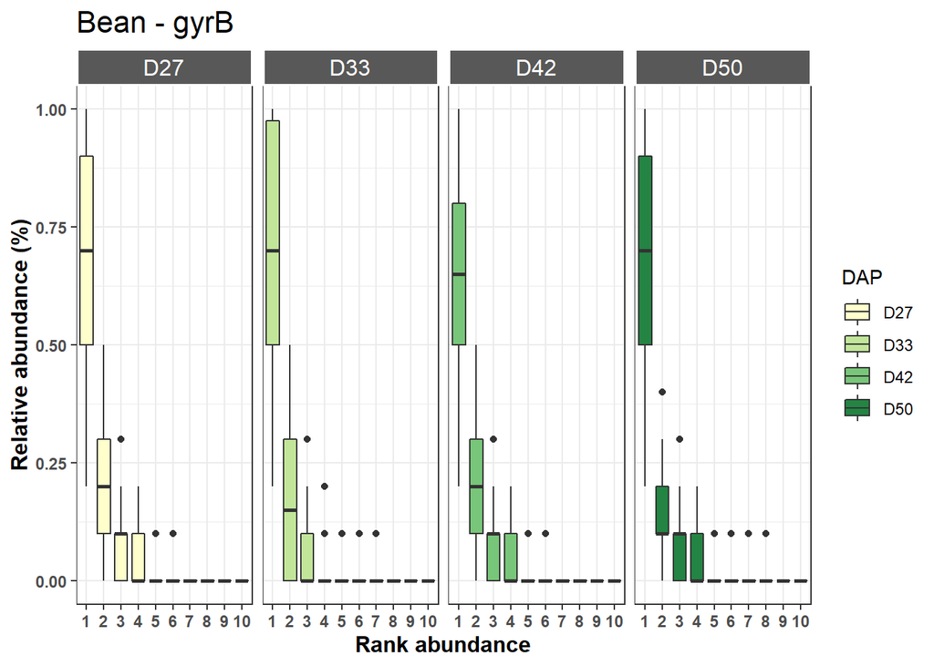

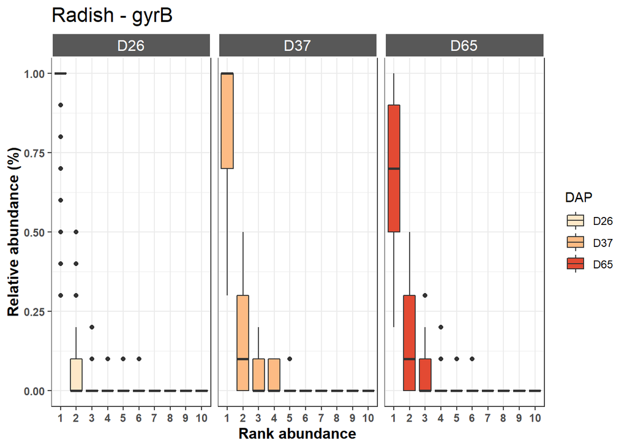

## 6.2 - Select first rank

## 6.3 - Create a phyloseq object

New phyloseq object with rank1 taxa only.

## 6.4 - Taxonomic composition

Here all seed communities are agglomerate at the individual plant level using only the 1st rank taxa.

```
## [1] '1.4.4'
```

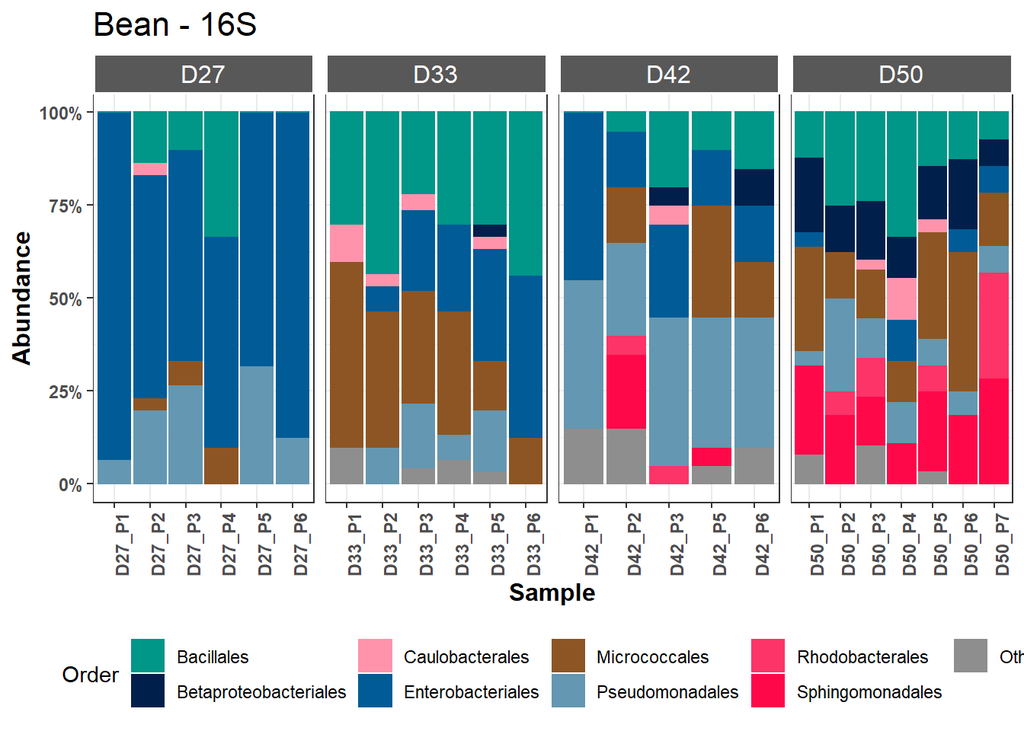

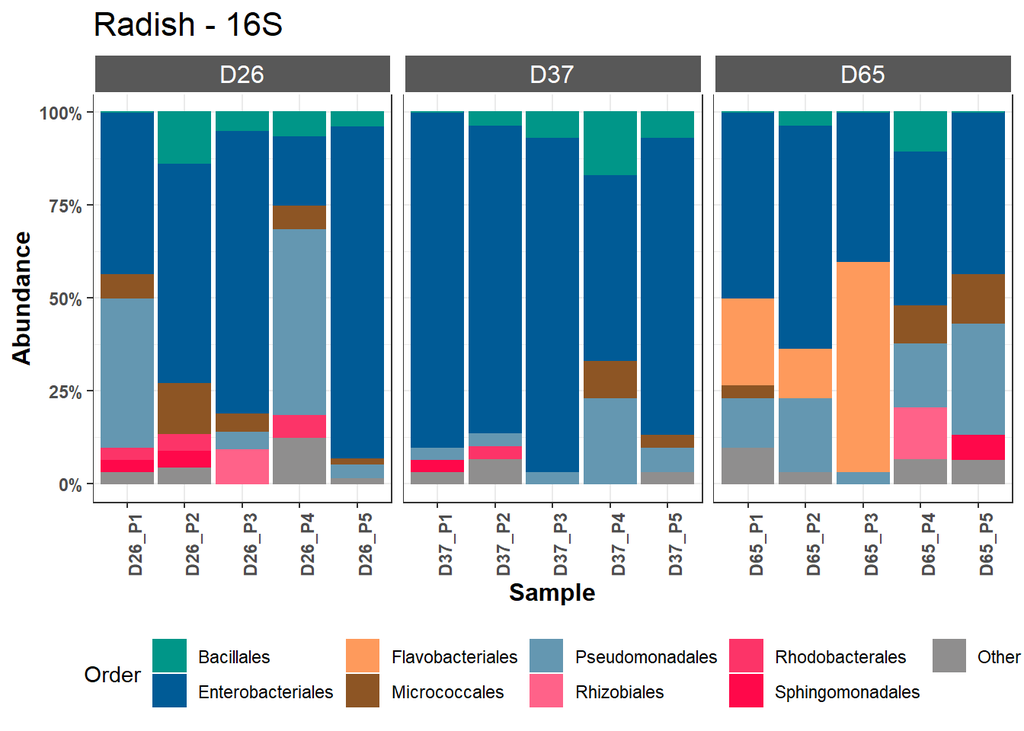

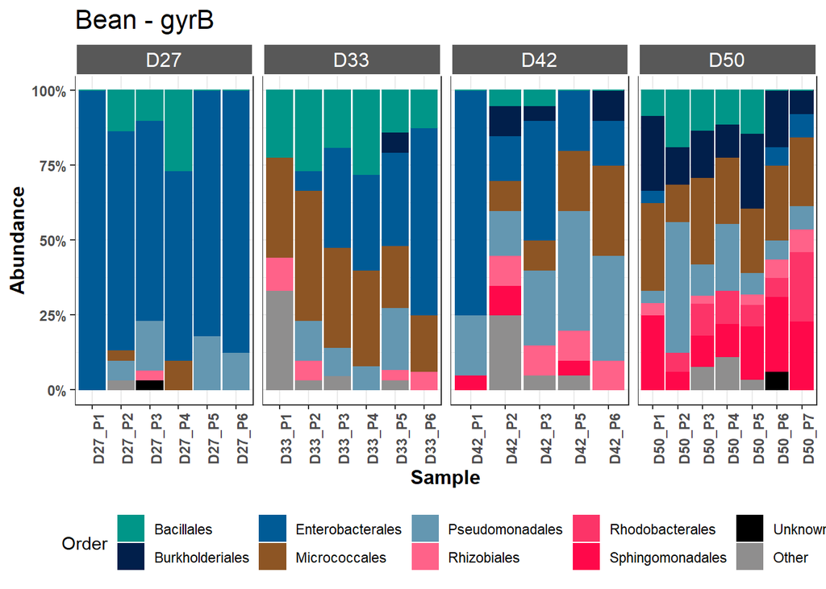

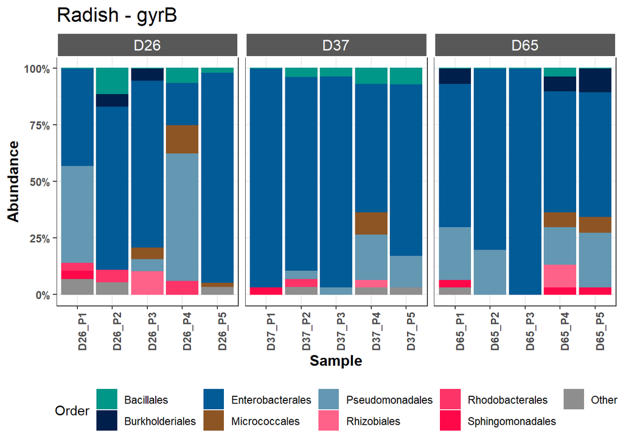

## 6.5 - Richness

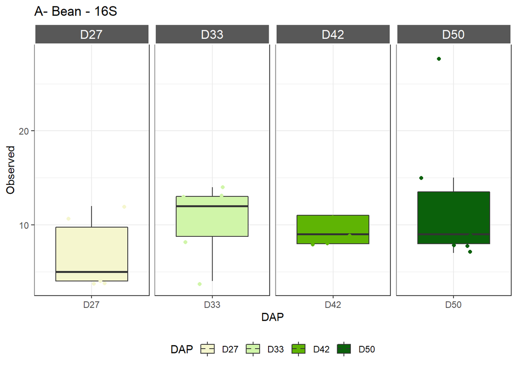

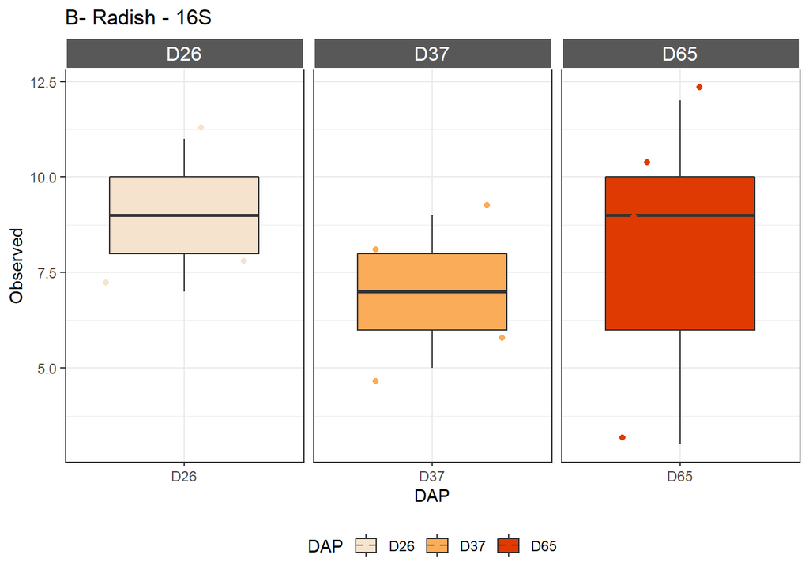

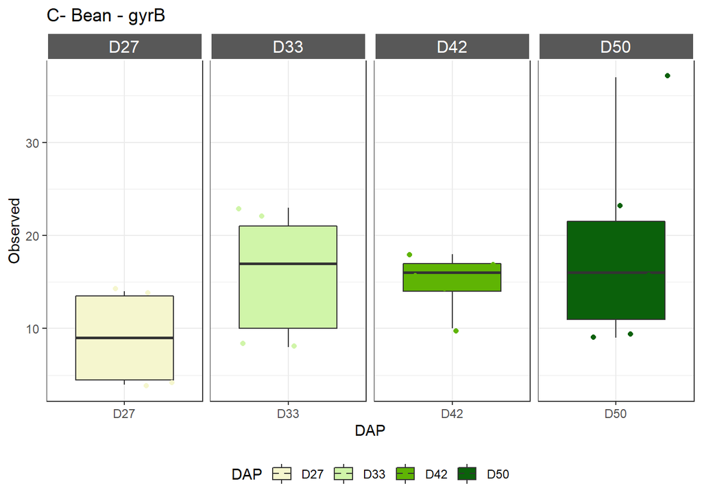

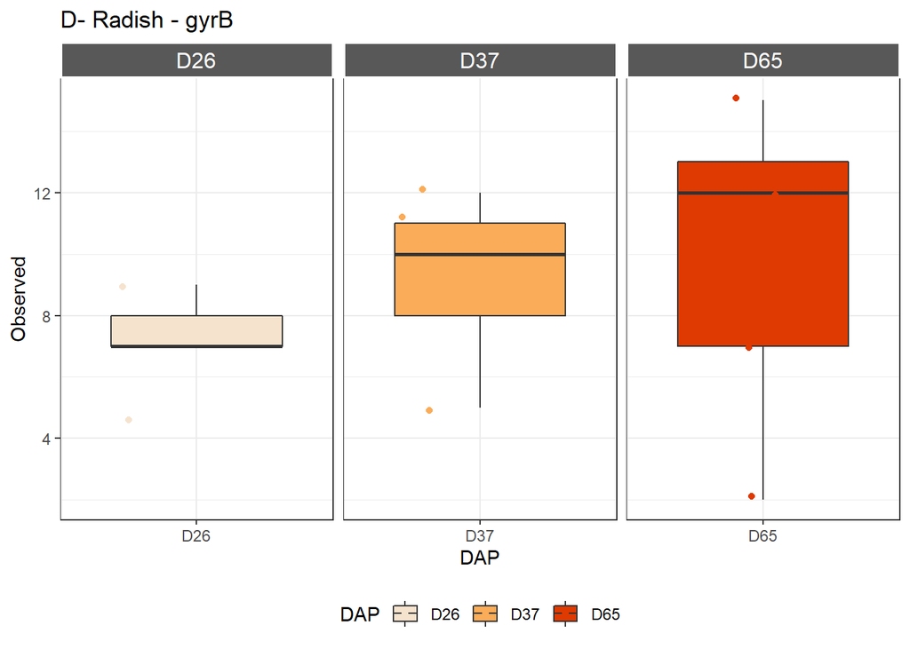

## 6.6 - Phylogenetic diversity

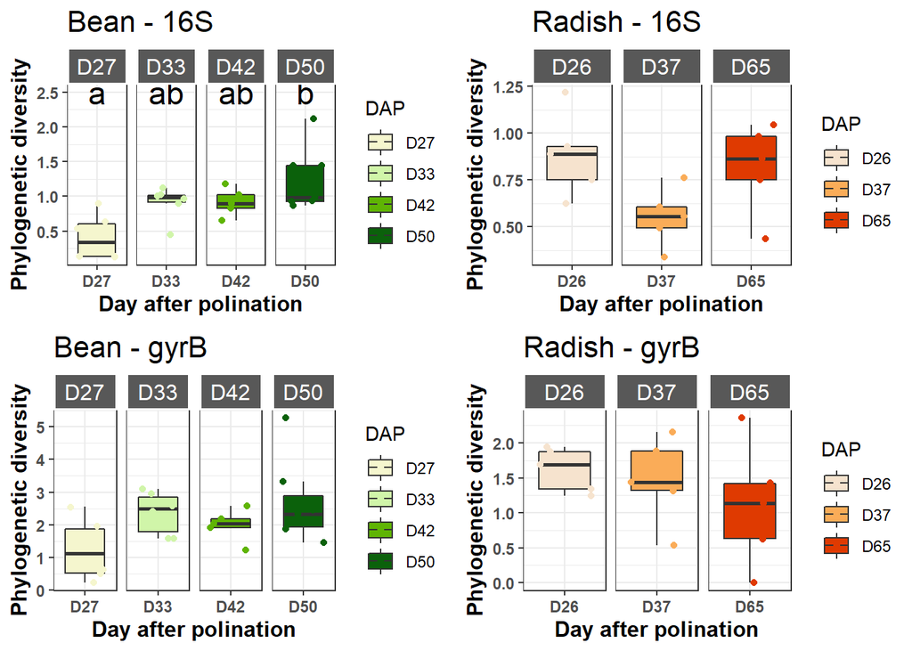

## 6.7 - Phylogenetic tree

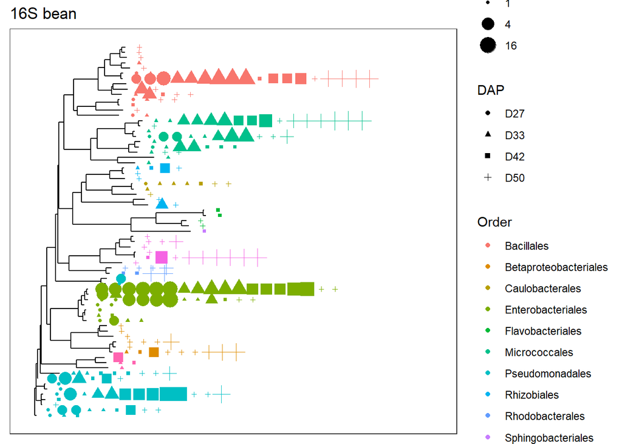

# 7 - Agglomerate all seed at individual plant level.

Here all seed communities are agglomerate at the individual plant level using all taxa and not only the 1st rank taxa. Since taxa abundance is distorted by the synthetic media (as well as PCR amplification), we first transform taxa abundance in presence/absence by sample and then merged per plant.

```
## [1] '1.32.0'
```

# 8 - Source microbiota analysis

Three different habitats have been sampled :

- Air (47 samples)
- Stem (5-6 samples per stage)
- Flower (5 samples)

Look at the distribution

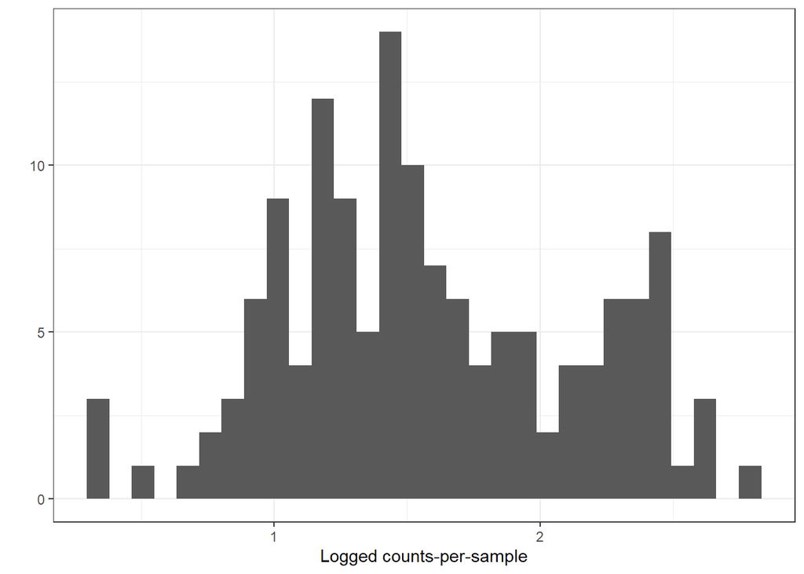

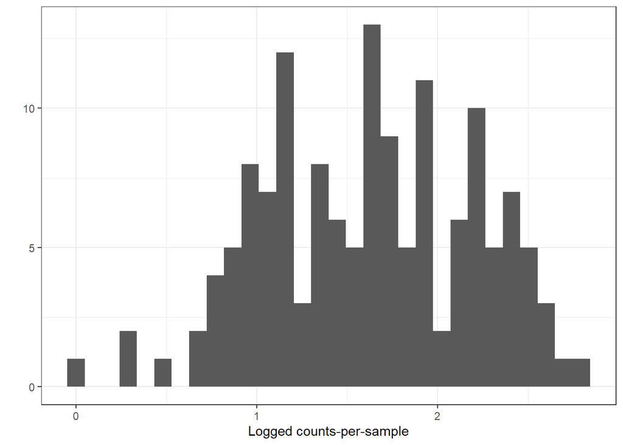

## 8.1 - Correlation habitat abundance relative Seeds

We performed correlation between the relative abundance of taxa in origin compared to seeds

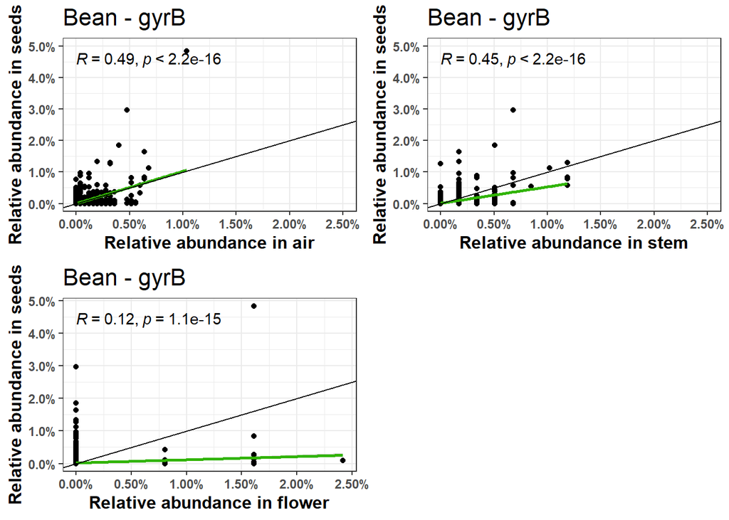

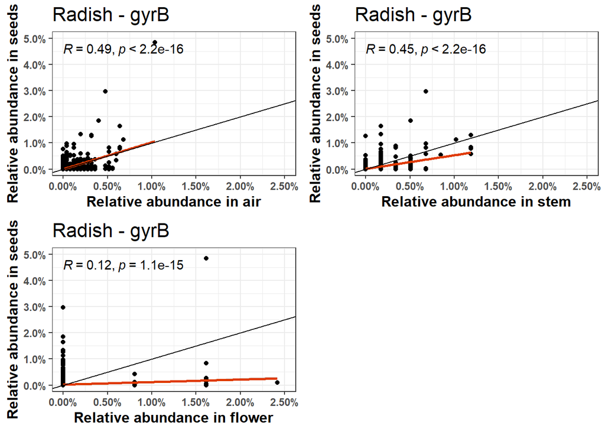

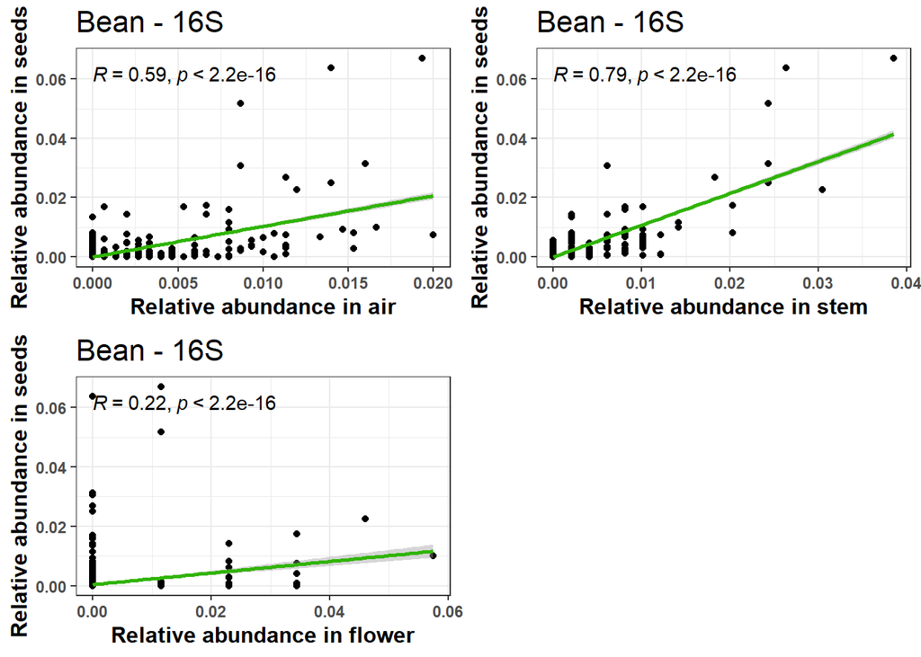

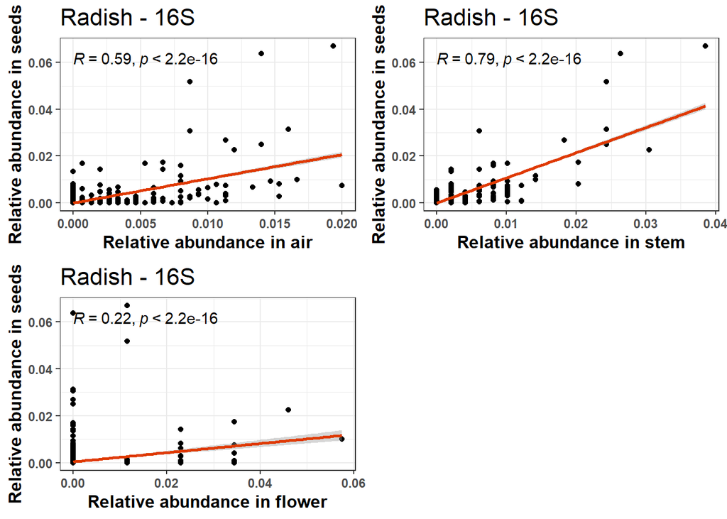